# Notebook

```
PLUMED: PLUMED is starting
PLUMED: Version: 2.8.0 (git: ddb59d16b) compiled on May 17 2022 at 19:07:56
PLUMED: Please cite these papers when using PLUMED [1][2]
PLUMED: For further information see the PLUMED web page at http://www.plumed.org
PLUMED: Root: /net/sbp/sbpstore1/bussi/miniconda3/envs/plumed-masterclass-2022/lib/plumed
PLUMED: For installed feature, see /net/sbp/sbpstore1/bussi/miniconda3/envs/plumed-masterclass-2022/lib/plumed/src/config/config.txt
PLUMED: Molecular dynamics engine: driver
PLUMED: Precision of reals: 8
PLUMED: Running over 1 node
PLUMED: Number of threads: 1
PLUMED: Cache line size: 512
PLUMED: Number of atoms: 1591
PLUMED: File suffix:
PLUMED: FILE: plumed.dat
PLUMED: Action MOLINFO
PLUMED:   with label @0
PLUMED:   pdb file named ../../../ala.pdb contains 1 chains
PLUMED:   chain named   contains residues 1 to 526 and atoms 1 to 1591
PLUMED: Action TORSION
PLUMED:   with label phi
PLUMED:   between atoms 5 7 9 15
PLUMED:   using periodic boundary conditions
PLUMED: Action TORSION
PLUMED:   with label psi
PLUMED:   between atoms 7 9 15 17
PLUMED:   using periodic boundary conditions
PLUMED: Action PRINT
PLUMED:   with label @3
PLUMED:   with stride 1
PLUMED:   with arguments phi psi
PLUMED:   on file COLVAR
PLUMED:   with format  %f
PLUMED: END FILE: plumed.dat
PLUMED: Timestep: 1.000000
PLUMED: KbT has not been set by the MD engine
PLUMED: It should be set by hand where needed
PLUMED: Relevant bibliography:
PLUMED:   [1] The PLUMED consortium, Nat. Methods 16, 670 (2019)
PLUMED:   [2] Tribello, Bonomi, Branduardi, Camilloni, and Bussi, Comput. Phys. Commun. 185, 604 (2014)
PLUMED: Please read and cite where appropriate!
PLUMED: Finished setup
PLUMED:                                               Cycles        Total      Average      Minimum      Maximum
PLUMED:                                                    1     0.091739     0.091739     0.091739     0.091739
PLUMED: 1 Prepare dependencies                          1001     0.001952     0.000002     0.000001     0.000013
PLUMED: 2 Sharing data                                  1001     0.010372     0.000010     0.000010     0.000279
PLUMED: 3 Waiting for data                              1001     0.003431     0.000003     0.000003     0.000021
PLUMED: 4 Calculating (forward loop)                    1001     0.011330     0.000011     0.000010     0.000045
PLUMED: 5 Applying (backward loop)                      1001     0.014659     0.000015     0.000014     0.000028
PLUMED: 6 Update                                        1001     0.009180     0.000009     0.000008     0.000061
```

```
+++ Loading the PLUMED kernel runtime +++
+++ PLUMED_KERNEL="/net/sbp/sbpstore1/bussi/miniconda3/envs/plumed-masterclass-2022/lib/libplumedKernel.so" +++
```

```
PLUMED: PLUMED is starting
PLUMED: Version: 2.8.0 (git: ddb59d16b) compiled on May 17 2022 at 19:07:56
PLUMED: Please cite these papers when using PLUMED [1][2]
PLUMED: For further information see the PLUMED web page at http://www.plumed.org
PLUMED: Root: /net/sbp/sbpstore1/bussi/miniconda3/envs/plumed-masterclass-2022/lib/plumed
PLUMED: For installed feature, see /net/sbp/sbpstore1/bussi/miniconda3/envs/plumed-masterclass-2022/lib/plumed/src/config/config.txt
PLUMED: Molecular dynamics engine: driver
PLUMED: Precision of reals: 8
PLUMED: Running over 1 node
PLUMED: Number of threads: 1
PLUMED: Cache line size: 512
PLUMED: Number of atoms: 1591
PLUMED: File suffix:
PLUMED: FILE: plumed.dat
PLUMED: Action MOLINFO
PLUMED:   with label @0
PLUMED:   pdb file named ../../../ala.pdb contains 1 chains
PLUMED:   chain named   contains residues 1 to 526 and atoms 1 to 1591
PLUMED: Action TORSION
PLUMED:   with label phi
PLUMED:   between atoms 5 7 9 15
PLUMED:   using periodic boundary conditions
PLUMED: Action TORSION
PLUMED:   with label psi
PLUMED:   between atoms 7 9 15 17
PLUMED:   using periodic boundary conditions
PLUMED: Action PRINT
PLUMED:   with label @3
PLUMED:   with stride 1
PLUMED:   with arguments phi psi
PLUMED:   on file COLVAR
PLUMED:   with format  %f
PLUMED: END FILE: plumed.dat
PLUMED: Timestep: 1.000000
PLUMED: KbT has not been set by the MD engine
PLUMED: It should be set by hand where needed
PLUMED: Relevant bibliography:
PLUMED:   [1] The PLUMED consortium, Nat. Methods 16, 670 (2019)
PLUMED:   [2] Tribello, Bonomi, Branduardi, Camilloni, and Bussi, Comput. Phys. Commun. 185, 604 (2014)
PLUMED: Please read and cite where appropriate!
PLUMED: Finished setup
PLUMED:                                               Cycles        Total      Average      Minimum      Maximum
PLUMED:                                                    1     0.091340     0.091340     0.091340     0.091340
PLUMED: 1 Prepare dependencies                          1001     0.002004     0.000002     0.000001     0.000007
PLUMED: 2 Sharing data                                  1001     0.010017     0.000010     0.000009     0.000261
PLUMED: 3 Waiting for data                              1001     0.003324     0.000003     0.000003     0.000020
PLUMED: 4 Calculating (forward loop)                    1001     0.011240     0.000011     0.000011     0.000043
PLUMED: 5 Applying (backward loop)                      1001     0.014565     0.000015     0.000014     0.000027
PLUMED: 6 Update                                        1001     0.009401     0.000009     0.000009     0.000059
```

```
+++ Loading the PLUMED kernel runtime +++
+++ PLUMED_KERNEL="/net/sbp/sbpstore1/bussi/miniconda3/envs/plumed-masterclass-2022/lib/libplumedKernel.so" +++
```

```
PLUMED: PLUMED is starting
PLUMED: Version: 2.8.0 (git: ddb59d16b) compiled on May 17 2022 at 19:07:56
PLUMED: Please cite these papers when using PLUMED [1][2]
PLUMED: For further information see the PLUMED web page at http://www.plumed.org
PLUMED: Root: /net/sbp/sbpstore1/bussi/miniconda3/envs/plumed-masterclass-2022/lib/plumed
PLUMED: For installed feature, see /net/sbp/sbpstore1/bussi/miniconda3/envs/plumed-masterclass-2022/lib/plumed/src/config/config.txt
PLUMED: Molecular dynamics engine: driver
PLUMED: Precision of reals: 8
PLUMED: Running over 1 node
PLUMED: Number of threads: 1
PLUMED: Cache line size: 512
PLUMED: Number of atoms: 1591
PLUMED: File suffix:
PLUMED: FILE: plumed.dat
PLUMED: Action MOLINFO
PLUMED:   with label @0
PLUMED:   pdb file named ../../../ala.pdb contains 1 chains
PLUMED:   chain named   contains residues 1 to 526 and atoms 1 to 1591
PLUMED: Action TORSION
PLUMED:   with label phi
PLUMED:   between atoms 5 7 9 15
PLUMED:   using periodic boundary conditions
PLUMED: Action TORSION
PLUMED:   with label psi
PLUMED:   between atoms 7 9 15 17
PLUMED:   using periodic boundary conditions
PLUMED: Action PRINT
PLUMED:   with label @3
PLUMED:   with stride 1
PLUMED:   with arguments phi psi
PLUMED:   on file COLVAR
PLUMED:   with format  %f
PLUMED: END FILE: plumed.dat
PLUMED: Timestep: 1.000000
PLUMED: KbT has not been set by the MD engine
PLUMED: It should be set by hand where needed
PLUMED: Relevant bibliography:
PLUMED:   [1] The PLUMED consortium, Nat. Methods 16, 670 (2019)
PLUMED:   [2] Tribello, Bonomi, Branduardi, Camilloni, and Bussi, Comput. Phys. Commun. 185, 604 (2014)
PLUMED: Please read and cite where appropriate!
PLUMED: Finished setup
PLUMED:                                               Cycles        Total      Average      Minimum      Maximum
PLUMED:                                                    1     0.090818     0.090818     0.090818     0.090818
PLUMED: 1 Prepare dependencies                          1001     0.001992     0.000002     0.000001     0.000007
PLUMED: 2 Sharing data                                  1001     0.010008     0.000010     0.000009     0.000272
PLUMED: 3 Waiting for data                              1001     0.003259     0.000003     0.000003     0.000020
PLUMED: 4 Calculating (forward loop)                    1001     0.011018     0.000011     0.000010     0.000043
PLUMED: 5 Applying (backward loop)                      1001     0.014499     0.000014     0.000014     0.000026
PLUMED: 6 Update                                        1001     0.009323     0.000009     0.000008     0.000061
```

```
+++ Loading the PLUMED kernel runtime +++
+++ PLUMED_KERNEL="/net/sbp/sbpstore1/bussi/miniconda3/envs/plumed-masterclass-2022/lib/libplumedKernel.so" +++
```

```
PLUMED: PLUMED is starting
PLUMED: Version: 2.8.0 (git: ddb59d16b) compiled on May 17 2022 at 19:07:56
PLUMED: Please cite these papers when using PLUMED [1][2]
PLUMED: For further information see the PLUMED web page at http://www.plumed.org
PLUMED: Root: /net/sbp/sbpstore1/bussi/miniconda3/envs/plumed-masterclass-2022/lib/plumed
PLUMED: For installed feature, see /net/sbp/sbpstore1/bussi/miniconda3/envs/plumed-masterclass-2022/lib/plumed/src/config/config.txt
PLUMED: Molecular dynamics engine: driver
PLUMED: Precision of reals: 8
PLUMED: Running over 1 node
PLUMED: Number of threads: 1
PLUMED: Cache line size: 512
PLUMED: Number of atoms: 1591
PLUMED: File suffix:
PLUMED: FILE: plumed.dat
PLUMED: Action MOLINFO
PLUMED:   with label @0
PLUMED:   pdb file named ../../../ala.pdb contains 1 chains
PLUMED:   chain named   contains residues 1 to 526 and atoms 1 to 1591
PLUMED: Action TORSION
PLUMED:   with label phi
PLUMED:   between atoms 5 7 9 15
PLUMED:   using periodic boundary conditions
PLUMED: Action TORSION
PLUMED:   with label psi
PLUMED:   between atoms 7 9 15 17
PLUMED:   using periodic boundary conditions
PLUMED: Action PRINT
PLUMED:   with label @3
PLUMED:   with stride 1
PLUMED:   with arguments phi psi
PLUMED:   on file COLVAR
PLUMED:   with format  %f
PLUMED: END FILE: plumed.dat
PLUMED: Timestep: 1.000000
PLUMED: KbT has not been set by the MD engine
PLUMED: It should be set by hand where needed
PLUMED: Relevant bibliography:
PLUMED:   [1] The PLUMED consortium, Nat. Methods 16, 670 (2019)
PLUMED:   [2] Tribello, Bonomi, Branduardi, Camilloni, and Bussi, Comput. Phys. Commun. 185, 604 (2014)
PLUMED: Please read and cite where appropriate!
PLUMED: Finished setup
PLUMED:                                               Cycles        Total      Average      Minimum      Maximum
PLUMED:                                                    1     0.091139     0.091139     0.091139     0.091139
PLUMED: 1 Prepare dependencies                          1001     0.002068     0.000002     0.000001     0.000011
PLUMED: 2 Sharing data                                  1001     0.010054     0.000010     0.000009     0.000258
PLUMED: 3 Waiting for data                              1001     0.003331     0.000003     0.000003     0.000020
PLUMED: 4 Calculating (forward loop)                    1001     0.011097     0.000011     0.000010     0.000043
PLUMED: 5 Applying (backward loop)                      1001     0.014529     0.000015     0.000014     0.000026
PLUMED: 6 Update                                        1001     0.009293     0.000009     0.000008     0.000060
```

```
+++ Loading the PLUMED kernel runtime +++
+++ PLUMED_KERNEL="/net/sbp/sbpstore1/bussi/miniconda3/envs/plumed-masterclass-2022/lib/libplumedKernel.so" +++
```

```
PLUMED: PLUMED is starting
PLUMED: Version: 2.8.0 (git: ddb59d16b) compiled on May 17 2022 at 19:07:56
PLUMED: Please cite these papers when using PLUMED [1][2]
PLUMED: For further information see the PLUMED web page at http://www.plumed.org
PLUMED: Root: /net/sbp/sbpstore1/bussi/miniconda3/envs/plumed-masterclass-2022/lib/plumed
PLUMED: For installed feature, see /net/sbp/sbpstore1/bussi/miniconda3/envs/plumed-masterclass-2022/lib/plumed/src/config/config.txt
PLUMED: Molecular dynamics engine: driver
PLUMED: Precision of reals: 8
PLUMED: Running over 1 node
PLUMED: Number of threads: 1
PLUMED: Cache line size: 512
PLUMED: Number of atoms: 1591
PLUMED: File suffix:
PLUMED: FILE: plumed.dat
PLUMED: Action MOLINFO
PLUMED:   with label @0
PLUMED:   pdb file named ../../../ala.pdb contains 1 chains
PLUMED:   chain named   contains residues 1 to 526 and atoms 1 to 1591
PLUMED: Action TORSION
PLUMED:   with label phi
PLUMED:   between atoms 5 7 9 15
PLUMED:   using periodic boundary conditions
PLUMED: Action TORSION
PLUMED:   with label psi
PLUMED:   between atoms 7 9 15 17
PLUMED:   using periodic boundary conditions
PLUMED: Action PRINT
PLUMED:   with label @3
PLUMED:   with stride 1
PLUMED:   with arguments phi psi
PLUMED:   on file COLVAR
PLUMED:   with format  %f
PLUMED: END FILE: plumed.dat
PLUMED: Timestep: 1.000000
PLUMED: KbT has not been set by the MD engine
PLUMED: It should be set by hand where needed
PLUMED: Relevant bibliography:
PLUMED:   [1] The PLUMED consortium, Nat. Methods 16, 670 (2019)
PLUMED:   [2] Tribello, Bonomi, Branduardi, Camilloni, and Bussi, Comput. Phys. Commun. 185, 604 (2014)
PLUMED: Please read and cite where appropriate!
PLUMED: Finished setup
PLUMED:                                               Cycles        Total      Average      Minimum      Maximum
PLUMED:                                                    1     0.091541     0.091541     0.091541     0.091541
PLUMED: 1 Prepare dependencies                          1001     0.002075     0.000002     0.000002     0.000007
PLUMED: 2 Sharing data                                  1001     0.010329     0.000010     0.000009     0.000260
PLUMED: 3 Waiting for data                              1001     0.003399     0.000003     0.000003     0.000021
PLUMED: 4 Calculating (forward loop)                    1001     0.011266     0.000011     0.000011     0.000044
PLUMED: 5 Applying (backward loop)                      1001     0.014753     0.000015     0.000014     0.000027
PLUMED: 6 Update                                        1001     0.009299     0.000009     0.000008     0.000060
```

```
+++ Loading the PLUMED kernel runtime +++
+++ PLUMED_KERNEL="/net/sbp/sbpstore1/bussi/miniconda3/envs/plumed-masterclass-2022/lib/libplumedKernel.so" +++
```

```
PLUMED: PLUMED is starting
PLUMED: Version: 2.8.0 (git: ddb59d16b) compiled on May 17 2022 at 19:07:56
PLUMED: Please cite these papers when using PLUMED [1][2]
PLUMED: For further information see the PLUMED web page at http://www.plumed.org
PLUMED: Root: /net/sbp/sbpstore1/bussi/miniconda3/envs/plumed-masterclass-2022/lib/plumed
PLUMED: For installed feature, see /net/sbp/sbpstore1/bussi/miniconda3/envs/plumed-masterclass-2022/lib/plumed/src/config/config.txt
PLUMED: Molecular dynamics engine: driver
PLUMED: Precision of reals: 8
PLUMED: Running over 1 node
PLUMED: Number of threads: 1
PLUMED: Cache line size: 512
PLUMED: Number of atoms: 1591
PLUMED: File suffix:
PLUMED: FILE: plumed.dat
PLUMED: Action MOLINFO
PLUMED:   with label @0
PLUMED:   pdb file named ../../../ala.pdb contains 1 chains
PLUMED:   chain named   contains residues 1 to 526 and atoms 1 to 1591
PLUMED: Action TORSION
PLUMED:   with label phi
PLUMED:   between atoms 5 7 9 15
PLUMED:   using periodic boundary conditions
PLUMED: Action TORSION
PLUMED:   with label psi
PLUMED:   between atoms 7 9 15 17
PLUMED:   using periodic boundary conditions
PLUMED: Action PRINT
PLUMED:   with label @3
PLUMED:   with stride 1
PLUMED:   with arguments phi psi
PLUMED:   on file COLVAR
PLUMED:   with format  %f
PLUMED: END FILE: plumed.dat
PLUMED: Timestep: 1.000000
PLUMED: KbT has not been set by the MD engine
PLUMED: It should be set by hand where needed
PLUMED: Relevant bibliography:
PLUMED:   [1] The PLUMED consortium, Nat. Methods 16, 670 (2019)
PLUMED:   [2] Tribello, Bonomi, Branduardi, Camilloni, and Bussi, Comput. Phys. Commun. 185, 604 (2014)
PLUMED: Please read and cite where appropriate!
PLUMED: Finished setup
PLUMED:                                               Cycles        Total      Average      Minimum      Maximum
PLUMED:                                                    1     0.091310     0.091310     0.091310     0.091310
PLUMED: 1 Prepare dependencies                          1001     0.002052     0.000002     0.000001     0.000007
PLUMED: 2 Sharing data                                  1001     0.009957     0.000010     0.000009     0.000259
PLUMED: 3 Waiting for data                              1001     0.003346     0.000003     0.000003     0.000021
PLUMED: 4 Calculating (forward loop)                    1001     0.011200     0.000011     0.000011     0.000054
PLUMED: 5 Applying (backward loop)                      1001     0.014763     0.000015     0.000014     0.000027
PLUMED: 6 Update                                        1001     0.009363     0.000009     0.000008     0.000061
```

```
+++ Loading the PLUMED kernel runtime +++
+++ PLUMED_KERNEL="/net/sbp/sbpstore1/bussi/miniconda3/envs/plumed-masterclass-2022/lib/libplumedKernel.so" +++
```

```
PLUMED: PLUMED is starting
PLUMED: Version: 2.8.0 (git: ddb59d16b) compiled on May 17 2022 at 19:07:56
PLUMED: Please cite these papers when using PLUMED [1][2]
PLUMED: For further information see the PLUMED web page at http://www.plumed.org
PLUMED: Root: /net/sbp/sbpstore1/bussi/miniconda3/envs/plumed-masterclass-2022/lib/plumed
PLUMED: For installed feature, see /net/sbp/sbpstore1/bussi/miniconda3/envs/plumed-masterclass-2022/lib/plumed/src/config/config.txt
PLUMED: Molecular dynamics engine: driver
PLUMED: Precision of reals: 8
PLUMED: Running over 1 node
PLUMED: Number of threads: 1
PLUMED: Cache line size: 512
PLUMED: Number of atoms: 1591
PLUMED: File suffix:
PLUMED: FILE: plumed.dat
PLUMED: Action MOLINFO
PLUMED:   with label @0
PLUMED:   pdb file named ../../../ala.pdb contains 1 chains
PLUMED:   chain named   contains residues 1 to 526 and atoms 1 to 1591
PLUMED: Action TORSION
PLUMED:   with label phi
PLUMED:   between atoms 5 7 9 15
PLUMED:   using periodic boundary conditions
PLUMED: Action TORSION
PLUMED:   with label psi
PLUMED:   between atoms 7 9 15 17
PLUMED:   using periodic boundary conditions
PLUMED: Action PRINT
PLUMED:   with label @3
PLUMED:   with stride 1
PLUMED:   with arguments phi psi
PLUMED:   on file COLVAR
PLUMED:   with format  %f
PLUMED: END FILE: plumed.dat
PLUMED: Timestep: 1.000000
PLUMED: KbT has not been set by the MD engine
PLUMED: It should be set by hand where needed
PLUMED: Relevant bibliography:
PLUMED:   [1] The PLUMED consortium, Nat. Methods 16, 670 (2019)
PLUMED:   [2] Tribello, Bonomi, Branduardi, Camilloni, and Bussi, Comput. Phys. Commun. 185, 604 (2014)
PLUMED: Please read and cite where appropriate!
```

[output cut: 35 more lines]

```
PLUMED: Action PRINT
PLUMED:   with label @3
PLUMED:   with stride 1
PLUMED:   with arguments phi psi
PLUMED:   on file COLVAR
PLUMED:   with format  %f
PLUMED: END FILE: plumed.dat
PLUMED: Timestep: 1.000000
PLUMED: KbT has not been set by the MD engine
PLUMED: It should be set by hand where needed
PLUMED: Relevant bibliography:
PLUMED:   [1] The PLUMED consortium, Nat. Methods 16, 670 (2019)
PLUMED:   [2] Tribello, Bonomi, Branduardi, Camilloni, and Bussi, Comput. Phys. Commun. 185, 604 (2014)
PLUMED: Please read and cite where appropriate!
PLUMED: Finished setup
```

```
+++ Loading the PLUMED kernel runtime +++
+++ PLUMED_KERNEL="/net/sbp/sbpstore1/bussi/miniconda3/envs/plumed-masterclass-2022/lib/libplumedKernel.so" +++
```

```
PLUMED:                                               Cycles        Total      Average      Minimum      Maximum
PLUMED:                                                    1     0.091801     0.091801     0.091801     0.091801
PLUMED: 1 Prepare dependencies                          1001     0.002049     0.000002     0.000001     0.000011
PLUMED: 2 Sharing data                                  1001     0.010117     0.000010     0.000009     0.000266
PLUMED: 3 Waiting for data                              1001     0.003427     0.000003     0.000003     0.000020
PLUMED: 4 Calculating (forward loop)                    1001     0.011202     0.000011     0.000010     0.000043
PLUMED: 5 Applying (backward loop)                      1001     0.014843     0.000015     0.000014     0.000028
PLUMED: 6 Update                                        1001     0.009571     0.000010     0.000009     0.000058
```

```
+++ Loading the PLUMED kernel runtime +++
+++ PLUMED_KERNEL="/net/sbp/sbpstore1/bussi/miniconda3/envs/plumed-masterclass-2022/lib/libplumedKernel.so" +++
```

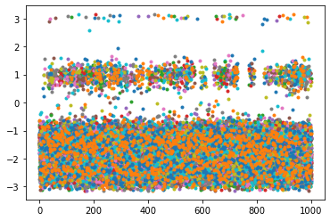

```python
for i in range(len(Ts)):
    plt.plot(colvar[i].time,colvar[i].phi,".")
```

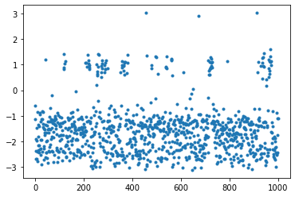

```python
plt.plot(colvar[i].time,colvar[31].phi,".")
```

```python
pop_pt=[]
for i in range(len(Ts)):
    pop_pt.append(
        np.sum(np.logical_and(colvar[i].phi<2.0,colvar[i].phi>0))/
        np.sum(np.logical_or(colvar[i].phi>2.0,colvar[i].phi<0))
    )
```

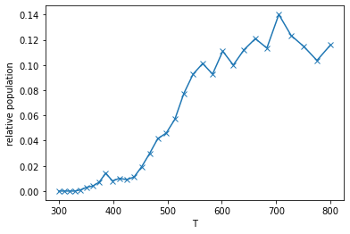

```python
plt.plot(Ts,pop_pt,"x-")
plt.xlabel("T")
plt.ylabel("relative population")
plt.show()
```

## Exercise 2a: Setting up scaled Hamiltonians

We now learn how to use the `plumed partial_tempering` tool to prepared scaled Hamiltonians. Notice that you could do the same using some other tool or editing by hand the top file.

The first thing that we have to do is to construct a self-contained top file

```python
with cd("2a"):
    run_mpi("gmx_mpi grompp -p ../topol.top -f ../grompp.mdp -c ../conf.gro -pp processed.top")
```

```
               :-) GROMACS - gmx grompp, 2020.6-plumed-2.8.0 (-:

                            GROMACS is written by:
     Emile Apol      Rossen Apostolov      Paul Bauer     Herman J.C. Berendsen
    Par Bjelkmar      Christian Blau   Viacheslav Bolnykh     Kevin Boyd
 Aldert van Buuren   Rudi van Drunen     Anton Feenstra       Alan Gray
  Gerrit Groenhof     Anca Hamuraru    Vincent Hindriksen  M. Eric Irrgang
  Aleksei Iupinov   Christoph Junghans     Joe Jordan     Dimitrios Karkoulis
    Peter Kasson        Jiri Kraus      Carsten Kutzner      Per Larsson
  Justin A. Lemkul    Viveca Lindahl    Magnus Lundborg     Erik Marklund
    Pascal Merz     Pieter Meulenhoff    Teemu Murtola       Szilard Pall
    Sander Pronk      Roland Schulz      Michael Shirts    Alexey Shvetsov
   Alfons Sijbers     Peter Tieleman      Jon Vincent      Teemu Virolainen
 Christian Wennberg    Maarten Wolf      Artem Zhmurov
                           and the project leaders:
        Mark Abraham, Berk Hess, Erik Lindahl, and David van der Spoel

Copyright (c) 1991-2000, University of Groningen, The Netherlands.
Copyright (c) 2001-2019, The GROMACS development team at
Uppsala University, Stockholm University and
the Royal Institute of Technology, Sweden.
check out http://www.gromacs.org for more information.

GROMACS is free software; you can redistribute it and/or modify it
under the terms of the GNU Lesser General Public License
as published by the Free Software Foundation; either version 2.1
of the License, or (at your option) any later version.

GROMACS:      gmx grompp, version 2020.6-plumed-2.8.0
Executable:   /net/sbp/sbpstore1/bussi/miniconda3/envs/plumed-masterclass-2022/bin/gmx_mpi
Data prefix:  /net/sbp/sbpstore1/bussi/miniconda3/envs/plumed-masterclass-2022
Working dir:  /scratch/bussi/masterclass-22-10-solution/2a
Command line:
  gmx_mpi grompp -p ../topol.top -f ../grompp.mdp -c ../conf.gro -pp processed.top

Setting the LD random seed to 2143280311

Back Off! I just backed up processed.top to ./#processed.top.1#
Generated 2145 of the 2145 non-bonded parameter combinations
Generating 1-4 interactions: fudge = 0.5
Generated 2145 of the 2145 1-4 parameter combinations
Excluding 3 bonded neighbours molecule type 'Protein'
Excluding 2 bonded neighbours molecule type 'SOL'
```

```
turning H bonds into constraints...
turning H bonds into constraints...
Analysing residue names:
There are:     3    Protein residues
There are:   523      Water residues
Analysing Protein...
Determining Verlet buffer for a tolerance of 0.005 kJ/mol/ps at 300 K
```

```
Number of degrees of freedom in T-Coupling group Protein is 53.95
Number of degrees of freedom in T-Coupling group SOL is 3135.05
Estimate for the relative computational load of the PME mesh part: 0.19

Back Off! I just backed up topol.tpr to ./#topol.tpr.1#

GROMACS reminds you: "This Puke Stinks Like Beer" (LIVE)
```

```
Calculated rlist for 1x1 atom pair-list as 1.036 nm, buffer size 0.036 nm
Set rlist, assuming 4x4 atom pair-list, to 1.000 nm, buffer size 0.000 nm
Note that mdrun will redetermine rlist based on the actual pair-list setup
Calculating fourier grid dimensions for X Y Z
Using a fourier grid of 24x24x24, spacing 0.118 0.118 0.118
This run will generate roughly 12 Mb of data
```

Then we can edit it. Usually this can be done with a text editor. However, if you want to batch process many systems, or do it in a notebook as here, you can use the following script:

```python
with cd("2a/"):
    with open("processed.top") as f:
        with open("processed_selected.top","w") as ff:
            in_molecules=False
            in_atoms=False
            ala_done=False
            for l in f:
                if(in_atoms) and not re.match(" *;.*",l) and not re.match(r"\[.*",l) and len(l.split())>2:
                    ll=l.split()
                    ll[1]=ll[1]+"_"
                    ll=" ".join(ll)
                    print(ll,file=ff)
                else:
                    print(l,end="",file=ff)
                if not ala_done and re.match(r"\[ *moleculetype *\]",l):
                    in_molecules=True
                    ala_done=True # track when alanine has been done so that we only modify that
                elif in_molecules and re.match(r"\[ *atoms *\]",l):
                    in_atoms=True
                elif re.match(r"\[.*",l):
                    in_molecules=False
                    in_atoms=False
    # then we generate two scaled topologies with factors 1.0 and 0.5
    run_mpi("plumed partial_tempering 1.0 < processed_selected.top > scaled1.0.top")
    run_mpi("plumed partial_tempering 0.5 < processed_selected.top > scaled0.5.top")
```

We can see the differences between the two scaled topologies:

- New atom types have been added (e.g., `C_`)
- Charges have been modified
- All torsions have been put "inline". No generic `HC CT C O` torsions, but specific `1 2 5 6` torsions. This allows to scale only portions of a molecule.

```python
!diff 2a/scaled1.0.top 2a/scaled0.5.top
```

```
40c40
< Br_ Br 79.90 0.0000 A 0.395559 1.33888  ; scaled
---
> Br_ Br 79.90 0.0000 A 0.395559 0.66944  ; scaled
42c42
< C_ C 12.01 0.0000 A 0.339967 0.359824  ; scaled
---
> C_ C 12.01 0.0000 A 0.339967 0.179912  ; scaled
44c44
< CA_ CA 12.01 0.0000 A 0.339967 0.359824  ; scaled
---
> CA_ CA 12.01 0.0000 A 0.339967 0.179912  ; scaled
46c46
< CB_ CB 12.01 0.0000 A 0.339967 0.359824  ; scaled
---
> CB_ CB 12.01 0.0000 A 0.339967 0.179912  ; scaled
48c48
< CC_ CC 12.01 0.0000 A 0.339967 0.359824  ; scaled
---
> CC_ CC 12.01 0.0000 A 0.339967 0.179912  ; scaled
50c50
< CK_ CK 12.01 0.0000 A 0.339967 0.359824  ; scaled
---
> CK_ CK 12.01 0.0000 A 0.339967 0.179912  ; scaled
52c52
< CM_ CM 12.01 0.0000 A 0.339967 0.359824  ; scaled
---
> CM_ CM 12.01 0.0000 A 0.339967 0.179912  ; scaled
54c54
< CN_ CN 12.01 0.0000 A 0.339967 0.359824  ; scaled
---
> CN_ CN 12.01 0.0000 A 0.339967 0.179912  ; scaled
56c56
< CQ_ CQ 12.01 0.0000 A 0.339967 0.359824  ; scaled
---
> CQ_ CQ 12.01 0.0000 A 0.339967 0.179912  ; scaled
58c58
< CR_ CR 12.01 0.0000 A 0.339967 0.359824  ; scaled
---
> CR_ CR 12.01 0.0000 A 0.339967 0.179912  ; scaled
```

[output cut: 361 more lines]

```
< 2 7 5 6 4 180.00 43.932 2
---
> 2 7 5 6 4 180.00 21.966 2
971c971
< 5 9 7 8 4 180.00 4.6024 2
---
> 5 9 7 8 4 180.00 2.3012 2
973c973
< 9 17 15 16 4 180.00 43.932 2
---
> 9 17 15 16 4 180.00 21.966 2
975c975
< 15 19 17 18 4 180.00 4.6024 2
---
> 15 19 17 18 4 180.00 2.3012 2
```

## Exercise 2b: Sanity check on generated topologies

We now do some sanity check on the resulting topologies. This is mostly to make sure that the `plumed partial_tempering` script edited them correctly.

To this aim we generate a short reference trajectory first (it's not important which force field we use at this step).

```python
with cd("2b"):
    run_mpi("gmx_mpi grompp -f ../grompp.mdp -c ../conf.gro -p ../topol.top")
    run_mpi("gmx_mpi mdrun -nsteps 5000")
```

```
               :-) GROMACS - gmx grompp, 2020.6-plumed-2.8.0 (-:

                            GROMACS is written by:
     Emile Apol      Rossen Apostolov      Paul Bauer     Herman J.C. Berendsen
    Par Bjelkmar      Christian Blau   Viacheslav Bolnykh     Kevin Boyd
 Aldert van Buuren   Rudi van Drunen     Anton Feenstra       Alan Gray
  Gerrit Groenhof     Anca Hamuraru    Vincent Hindriksen  M. Eric Irrgang
  Aleksei Iupinov   Christoph Junghans     Joe Jordan     Dimitrios Karkoulis
    Peter Kasson        Jiri Kraus      Carsten Kutzner      Per Larsson
  Justin A. Lemkul    Viveca Lindahl    Magnus Lundborg     Erik Marklund
    Pascal Merz     Pieter Meulenhoff    Teemu Murtola       Szilard Pall
    Sander Pronk      Roland Schulz      Michael Shirts    Alexey Shvetsov
   Alfons Sijbers     Peter Tieleman      Jon Vincent      Teemu Virolainen
 Christian Wennberg    Maarten Wolf      Artem Zhmurov
                           and the project leaders:
        Mark Abraham, Berk Hess, Erik Lindahl, and David van der Spoel

Copyright (c) 1991-2000, University of Groningen, The Netherlands.
Copyright (c) 2001-2019, The GROMACS development team at
Uppsala University, Stockholm University and
the Royal Institute of Technology, Sweden.
check out http://www.gromacs.org for more information.

GROMACS is free software; you can redistribute it and/or modify it
under the terms of the GNU Lesser General Public License
as published by the Free Software Foundation; either version 2.1
of the License, or (at your option) any later version.

GROMACS:      gmx grompp, version 2020.6-plumed-2.8.0
Executable:   /net/sbp/sbpstore1/bussi/miniconda3/envs/plumed-masterclass-2022/bin/gmx_mpi
Data prefix:  /net/sbp/sbpstore1/bussi/miniconda3/envs/plumed-masterclass-2022
Working dir:  /scratch/bussi/masterclass-22-10-solution/2b
Command line:
  gmx_mpi grompp -f ../grompp.mdp -c ../conf.gro -p ../topol.top

Setting the LD random seed to -80025769
Generated 2145 of the 2145 non-bonded parameter combinations
Generating 1-4 interactions: fudge = 0.5
Generated 2145 of the 2145 1-4 parameter combinations
Excluding 3 bonded neighbours molecule type 'Protein'
Excluding 2 bonded neighbours molecule type 'SOL'
```

```
turning H bonds into constraints...
turning H bonds into constraints...
Analysing residue names:
There are:     3    Protein residues
There are:   523      Water residues
Analysing Protein...
```

```
Number of degrees of freedom in T-Coupling group Protein is 53.95
Number of degrees of freedom in T-Coupling group SOL is 3135.05
Estimate for the relative computational load of the PME mesh part: 0.19
```

```
Determining Verlet buffer for a tolerance of 0.005 kJ/mol/ps at 300 K
Calculated rlist for 1x1 atom pair-list as 1.036 nm, buffer size 0.036 nm
Set rlist, assuming 4x4 atom pair-list, to 1.000 nm, buffer size 0.000 nm
Note that mdrun will redetermine rlist based on the actual pair-list setup
Calculating fourier grid dimensions for X Y Z
Using a fourier grid of 24x24x24, spacing 0.118 0.118 0.118
This run will generate roughly 12 Mb of data
```

```
Back Off! I just backed up topol.tpr to ./#topol.tpr.1#

GROMACS reminds you: "It all works because Avogadro's number is closer to infinity than to 10." (Ralph Baierlein)

                :-) GROMACS - gmx mdrun, 2020.6-plumed-2.8.0 (-:

                            GROMACS is written by:
     Emile Apol      Rossen Apostolov      Paul Bauer     Herman J.C. Berendsen
    Par Bjelkmar      Christian Blau   Viacheslav Bolnykh     Kevin Boyd
 Aldert van Buuren   Rudi van Drunen     Anton Feenstra       Alan Gray
  Gerrit Groenhof     Anca Hamuraru    Vincent Hindriksen  M. Eric Irrgang
  Aleksei Iupinov   Christoph Junghans     Joe Jordan     Dimitrios Karkoulis
    Peter Kasson        Jiri Kraus      Carsten Kutzner      Per Larsson
  Justin A. Lemkul    Viveca Lindahl    Magnus Lundborg     Erik Marklund
    Pascal Merz     Pieter Meulenhoff    Teemu Murtola       Szilard Pall
    Sander Pronk      Roland Schulz      Michael Shirts    Alexey Shvetsov
   Alfons Sijbers     Peter Tieleman      Jon Vincent      Teemu Virolainen
 Christian Wennberg    Maarten Wolf      Artem Zhmurov
                           and the project leaders:
        Mark Abraham, Berk Hess, Erik Lindahl, and David van der Spoel

Copyright (c) 1991-2000, University of Groningen, The Netherlands.
Copyright (c) 2001-2019, The GROMACS development team at
Uppsala University, Stockholm University and
the Royal Institute of Technology, Sweden.
check out http://www.gromacs.org for more information.

GROMACS is free software; you can redistribute it and/or modify it
under the terms of the GNU Lesser General Public License
as published by the Free Software Foundation; either version 2.1
of the License, or (at your option) any later version.

GROMACS:      gmx mdrun, version 2020.6-plumed-2.8.0
Executable:   /net/sbp/sbpstore1/bussi/miniconda3/envs/plumed-masterclass-2022/bin/gmx_mpi
Data prefix:  /net/sbp/sbpstore1/bussi/miniconda3/envs/plumed-masterclass-2022
Working dir:  /scratch/bussi/masterclass-22-10-solution/2b
Command line:
  gmx_mpi mdrun -nsteps 5000


```

[output cut: 22 more lines]

```
starting mdrun 'alanine dipeptide in vacuum in water'
5000 steps,     10.0 ps.

Writing final coordinates.

Back Off! I just backed up confout.gro to ./#confout.gro.1#

NOTE: Detected invalid cycle counts, probably because threads moved between CPU cores that do not have synchronized cycle counters. Will not print the cycle accounting.

               Core t (s)   Wall t (s)        (%)
       Time:     1958.671       81.611     2400.0
                 (ns/day)    (hour/ns)
Performance:       10.589        2.267

GROMACS reminds you: "If I Wanted You to Understand This, I Would Explain it Better" (J. Cruijff)
```

We then "rerun" its energy with different topologies. Specifically, we use the original tpr file and a new one obtained from topol_scaled1.0.top, which has been obtained with scaling factor 1.0. The two calculations should return identical energies

```python
with cd("2b"):
    run_mpi("cp ../2a/processed_selected.top processed_selected.top")
    run_mpi("plumed partial_tempering 1.0 < processed_selected.top > topol_scaled1.0.top")
    run_mpi("gmx_mpi grompp -f ../grompp.mdp -c ../conf.gro -p topol_scaled1.0.top -o topol_scaled1.0.tpr")
    with cd("rerun0"):
        run_mpi("gmx_mpi mdrun -rerun ../traj_comp.xtc -s ../topol.tpr")
        run_mpi("echo 1 2 3 4 5 6 7 8 9 10 11 | gmx_mpi energy -xvg no")
    with cd("rerun1"):
        run_mpi("gmx_mpi mdrun -rerun ../traj_comp.xtc -s ../topol_scaled1.0.tpr")
        run_mpi("echo 1 2 3 4 5 6 7 8 9 10 11 | gmx_mpi energy -xvg no")
```

```
               :-) GROMACS - gmx grompp, 2020.6-plumed-2.8.0 (-:

                            GROMACS is written by:
     Emile Apol      Rossen Apostolov      Paul Bauer     Herman J.C. Berendsen
    Par Bjelkmar      Christian Blau   Viacheslav Bolnykh     Kevin Boyd
 Aldert van Buuren   Rudi van Drunen     Anton Feenstra       Alan Gray
  Gerrit Groenhof     Anca Hamuraru    Vincent Hindriksen  M. Eric Irrgang
  Aleksei Iupinov   Christoph Junghans     Joe Jordan     Dimitrios Karkoulis
    Peter Kasson        Jiri Kraus      Carsten Kutzner      Per Larsson
  Justin A. Lemkul    Viveca Lindahl    Magnus Lundborg     Erik Marklund
    Pascal Merz     Pieter Meulenhoff    Teemu Murtola       Szilard Pall
    Sander Pronk      Roland Schulz      Michael Shirts    Alexey Shvetsov
   Alfons Sijbers     Peter Tieleman      Jon Vincent      Teemu Virolainen
 Christian Wennberg    Maarten Wolf      Artem Zhmurov
                           and the project leaders:
        Mark Abraham, Berk Hess, Erik Lindahl, and David van der Spoel

Copyright (c) 1991-2000, University of Groningen, The Netherlands.
Copyright (c) 2001-2019, The GROMACS development team at
Uppsala University, Stockholm University and
the Royal Institute of Technology, Sweden.
check out http://www.gromacs.org for more information.

GROMACS is free software; you can redistribute it and/or modify it
under the terms of the GNU Lesser General Public License
as published by the Free Software Foundation; either version 2.1
of the License, or (at your option) any later version.

GROMACS:      gmx grompp, version 2020.6-plumed-2.8.0
Executable:   /net/sbp/sbpstore1/bussi/miniconda3/envs/plumed-masterclass-2022/bin/gmx_mpi
Data prefix:  /net/sbp/sbpstore1/bussi/miniconda3/envs/plumed-masterclass-2022
Working dir:  /scratch/bussi/masterclass-22-10-solution/2b
Command line:
  gmx_mpi grompp -f ../grompp.mdp -c ../conf.gro -p topol_scaled1.0.top -o topol_scaled1.0.tpr

Setting the LD random seed to 2079717087
Generated 8515 of the 8515 non-bonded parameter combinations
Generating 1-4 interactions: fudge = 0.5
Generated 8515 of the 8515 1-4 parameter combinations
Excluding 3 bonded neighbours molecule type 'Protein'
Excluding 2 bonded neighbours molecule type 'SOL'
```

```
turning H bonds into constraints...
turning H bonds into constraints...
Analysing residue names:
There are:     3    Protein residues
There are:   523      Water residues
Analysing Protein...
Determining Verlet buffer for a tolerance of 0.005 kJ/mol/ps at 300 K
```

```
Number of degrees of freedom in T-Coupling group Protein is 53.95
Number of degrees of freedom in T-Coupling group SOL is 3135.05
```

```
Calculated rlist for 1x1 atom pair-list as 1.036 nm, buffer size 0.036 nm
Set rlist, assuming 4x4 atom pair-list, to 1.000 nm, buffer size 0.000 nm
Note that mdrun will redetermine rlist based on the actual pair-list setup
Calculating fourier grid dimensions for X Y Z
Using a fourier grid of 24x24x24, spacing 0.118 0.118 0.118
This run will generate roughly 12 Mb of data
```

```
Estimate for the relative computational load of the PME mesh part: 0.19

Back Off! I just backed up topol_scaled1.0.tpr to ./#topol_scaled1.0.tpr.1#

GROMACS reminds you: "There are only two hard things in computer science - cache invalidation, naming things and off-by-one errors." (Anonymous)

                :-) GROMACS - gmx mdrun, 2020.6-plumed-2.8.0 (-:

                            GROMACS is written by:
     Emile Apol      Rossen Apostolov      Paul Bauer     Herman J.C. Berendsen
    Par Bjelkmar      Christian Blau   Viacheslav Bolnykh     Kevin Boyd
 Aldert van Buuren   Rudi van Drunen     Anton Feenstra       Alan Gray
  Gerrit Groenhof     Anca Hamuraru    Vincent Hindriksen  M. Eric Irrgang
  Aleksei Iupinov   Christoph Junghans     Joe Jordan     Dimitrios Karkoulis
    Peter Kasson        Jiri Kraus      Carsten Kutzner      Per Larsson
  Justin A. Lemkul    Viveca Lindahl    Magnus Lundborg     Erik Marklund
    Pascal Merz     Pieter Meulenhoff    Teemu Murtola       Szilard Pall
    Sander Pronk      Roland Schulz      Michael Shirts    Alexey Shvetsov
   Alfons Sijbers     Peter Tieleman      Jon Vincent      Teemu Virolainen
 Christian Wennberg    Maarten Wolf      Artem Zhmurov
                           and the project leaders:
        Mark Abraham, Berk Hess, Erik Lindahl, and David van der Spoel

Copyright (c) 1991-2000, University of Groningen, The Netherlands.
Copyright (c) 2001-2019, The GROMACS development team at
Uppsala University, Stockholm University and
the Royal Institute of Technology, Sweden.
check out http://www.gromacs.org for more information.

GROMACS is free software; you can redistribute it and/or modify it
under the terms of the GNU Lesser General Public License
as published by the Free Software Foundation; either version 2.1
of the License, or (at your option) any later version.

GROMACS:      gmx mdrun, version 2020.6-plumed-2.8.0
Executable:   /net/sbp/sbpstore1/bussi/miniconda3/envs/plumed-masterclass-2022/bin/gmx_mpi
Data prefix:  /net/sbp/sbpstore1/bussi/miniconda3/envs/plumed-masterclass-2022
Working dir:  /scratch/bussi/masterclass-22-10-solution/2b/rerun0
Command line:
  gmx_mpi mdrun -rerun ../traj_comp.xtc -s ../topol.tpr
```

[output cut: 69 more lines]

```
Opened ener.edr as single precision energy file

Select the terms you want from the following list by
selecting either (part of) the name or the number or a combination.
End your selection with an empty line or a zero.
-------------------------------------------------------------------
  1  Bond             2  Angle            3  Proper-Dih.      4  Improper-Dih.
  5  LJ-14            6  Coulomb-14       7  LJ-(SR)          8  Disper.-corr.
  9  Coulomb-(SR)    10  Coul.-recip.    11  Potential


Back Off! I just backed up energy.xvg to ./#energy.xvg.1#
Last energy frame read 10 time   10.000

GROMACS reminds you: "#define QUESTION ((bb),| !(bb))" (William Shakespeare)
```

```
Statistics over 5001 steps [ 0.0000 through 10.0000 ps ], 11 data sets
All statistics are over 11 points (frames)

Energy                      Average   Err.Est.       RMSD  Tot-Drift
-------------------------------------------------------------------------------
Bond                        12.8501       0.93    5.54295    1.76035  (kJ/mol)
Angle                       31.4149        3.3    9.29962   -14.1766  (kJ/mol)
Proper Dih.                 45.7409        1.7    4.41161   -2.62365  (kJ/mol)
Improper Dih.               2.41675       0.48    1.38529  -0.191024  (kJ/mol)
LJ-14                       13.6088        1.6    4.45048    3.70408  (kJ/mol)
Coulomb-14                  195.498        2.7     6.9361   -11.1147  (kJ/mol)
LJ (SR)                     3321.67         54    169.128    -173.23  (kJ/mol)
Disper. corr.              -188.172          0          0          0  (kJ/mol)
Coulomb (SR)               -24668.2         78    291.718    198.491  (kJ/mol)
Coul. recip.                135.806        3.5    12.0772  0.0296166  (kJ/mol)
Potential                  -21097.4         45    203.431    2.64933  (kJ/mol)
```

```
                :-) GROMACS - gmx mdrun, 2020.6-plumed-2.8.0 (-:

                            GROMACS is written by:
     Emile Apol      Rossen Apostolov      Paul Bauer     Herman J.C. Berendsen
    Par Bjelkmar      Christian Blau   Viacheslav Bolnykh     Kevin Boyd
 Aldert van Buuren   Rudi van Drunen     Anton Feenstra       Alan Gray
  Gerrit Groenhof     Anca Hamuraru    Vincent Hindriksen  M. Eric Irrgang
  Aleksei Iupinov   Christoph Junghans     Joe Jordan     Dimitrios Karkoulis
    Peter Kasson        Jiri Kraus      Carsten Kutzner      Per Larsson
  Justin A. Lemkul    Viveca Lindahl    Magnus Lundborg     Erik Marklund
    Pascal Merz     Pieter Meulenhoff    Teemu Murtola       Szilard Pall
    Sander Pronk      Roland Schulz      Michael Shirts    Alexey Shvetsov
   Alfons Sijbers     Peter Tieleman      Jon Vincent      Teemu Virolainen
 Christian Wennberg    Maarten Wolf      Artem Zhmurov
                           and the project leaders:
        Mark Abraham, Berk Hess, Erik Lindahl, and David van der Spoel

Copyright (c) 1991-2000, University of Groningen, The Netherlands.
Copyright (c) 2001-2019, The GROMACS development team at
Uppsala University, Stockholm University and
the Royal Institute of Technology, Sweden.
check out http://www.gromacs.org for more information.

GROMACS is free software; you can redistribute it and/or modify it
under the terms of the GNU Lesser General Public License
as published by the Free Software Foundation; either version 2.1
of the License, or (at your option) any later version.

GROMACS:      gmx mdrun, version 2020.6-plumed-2.8.0
Executable:   /net/sbp/sbpstore1/bussi/miniconda3/envs/plumed-masterclass-2022/bin/gmx_mpi
Data prefix:  /net/sbp/sbpstore1/bussi/miniconda3/envs/plumed-masterclass-2022
Working dir:  /scratch/bussi/masterclass-22-10-solution/2b/rerun1
Command line:
  gmx_mpi mdrun -rerun ../traj_comp.xtc -s ../topol_scaled1.0.tpr


Back Off! I just backed up md.log to ./#md.log.1#
Compiled SIMD: SSE2, but for this host/run AVX_256 might be better (see log).
The current CPU can measure timings more accurately than the code in
gmx mdrun was configured to use. This might affect your simulation
```

[output cut: 12 more lines]

```

Back Off! I just backed up ener.edr to ./#ener.edr.1#
starting md rerun 'alanine dipeptide in vacuum in water', reading coordinates from input trajectory '../traj_comp.xtc'

Last frame         10 time   10.000

NOTE: 36 % of the run time was spent in pair search,
      you might want to increase nstlist (this has no effect on accuracy)

               Core t (s)   Wall t (s)        (%)
       Time:        6.654        0.277     2398.9
                 (ns/day)    (hour/ns)
Performance:     3115.312        0.008

GROMACS reminds you: "Take Your Medications and Preparations and Ram It Up Your Snout" (F. Zappa)
```

```
Statistics over 5001 steps [ 0.0000 through 10.0000 ps ], 11 data sets
All statistics are over 11 points (frames)

Energy                      Average   Err.Est.       RMSD  Tot-Drift
-------------------------------------------------------------------------------
Bond                        12.8501       0.93    5.54295    1.76035  (kJ/mol)
Angle                       31.4149        3.3    9.29962   -14.1766  (kJ/mol)
Proper Dih.                 45.7409        1.7    4.41161   -2.62365  (kJ/mol)
Improper Dih.               2.41675       0.48    1.38529  -0.191024  (kJ/mol)
LJ-14                       13.6088        1.6    4.45048    3.70408  (kJ/mol)
Coulomb-14                  195.498        2.7     6.9361   -11.1147  (kJ/mol)
LJ (SR)                     3321.67         54    169.128    -173.23  (kJ/mol)
Disper. corr.              -188.172          0          0          0  (kJ/mol)
Coulomb (SR)               -24668.2         78    291.718    198.491  (kJ/mol)
Coul. recip.                135.806        3.5    12.0772  0.0296645  (kJ/mol)
Potential                  -21097.4         45    203.431    2.64933  (kJ/mol)
```

```
               :-) GROMACS - gmx energy, 2020.6-plumed-2.8.0 (-:

                            GROMACS is written by:
     Emile Apol      Rossen Apostolov      Paul Bauer     Herman J.C. Berendsen
    Par Bjelkmar      Christian Blau   Viacheslav Bolnykh     Kevin Boyd
 Aldert van Buuren   Rudi van Drunen     Anton Feenstra       Alan Gray
  Gerrit Groenhof     Anca Hamuraru    Vincent Hindriksen  M. Eric Irrgang
  Aleksei Iupinov   Christoph Junghans     Joe Jordan     Dimitrios Karkoulis
    Peter Kasson        Jiri Kraus      Carsten Kutzner      Per Larsson
  Justin A. Lemkul    Viveca Lindahl    Magnus Lundborg     Erik Marklund
    Pascal Merz     Pieter Meulenhoff    Teemu Murtola       Szilard Pall
    Sander Pronk      Roland Schulz      Michael Shirts    Alexey Shvetsov
   Alfons Sijbers     Peter Tieleman      Jon Vincent      Teemu Virolainen
 Christian Wennberg    Maarten Wolf      Artem Zhmurov
                           and the project leaders:
        Mark Abraham, Berk Hess, Erik Lindahl, and David van der Spoel

Copyright (c) 1991-2000, University of Groningen, The Netherlands.
Copyright (c) 2001-2019, The GROMACS development team at
Uppsala University, Stockholm University and
the Royal Institute of Technology, Sweden.
check out http://www.gromacs.org for more information.

GROMACS is free software; you can redistribute it and/or modify it
under the terms of the GNU Lesser General Public License
as published by the Free Software Foundation; either version 2.1
of the License, or (at your option) any later version.

GROMACS:      gmx energy, version 2020.6-plumed-2.8.0
Executable:   /net/sbp/sbpstore1/bussi/miniconda3/envs/plumed-masterclass-2022/bin/gmx_mpi
Data prefix:  /net/sbp/sbpstore1/bussi/miniconda3/envs/plumed-masterclass-2022
Working dir:  /scratch/bussi/masterclass-22-10-solution/2b/rerun1
Command line:
  gmx_mpi energy -xvg no

Opened ener.edr as single precision energy file

Select the terms you want from the following list by
selecting either (part of) the name or the number or a combination.
End your selection with an empty line or a zero.
-------------------------------------------------------------------
  1  Bond             2  Angle            3  Proper-Dih.      4  Improper-Dih.
  5  LJ-14            6  Coulomb-14       7  LJ-(SR)          8  Disper.-corr.
  9  Coulomb-(SR)    10  Coul.-recip.    11  Potential


Back Off! I just backed up energy.xvg to ./#energy.xvg.1#
Last energy frame read 10 time   10.000

GROMACS reminds you: "To survive science you have to become science." (Gerrit Groenhof)
```

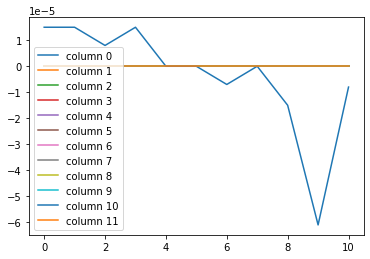

```python
ene=pandas.read_csv("2b/rerun0/energy.xvg",header=None,delim_whitespace=True)
ene_scaled=pandas.read_csv("2b/rerun1/energy.xvg",header=None,delim_whitespace=True)
difference=np.array(ene)-np.array(ene_scaled)
for i in range(difference.shape[1]):
    plt.plot(difference[:,i],label="column {}".format(i))
plt.legend()
plt.show()
```

Only column 10 (long range Ewald) has some minor difference (1e-5), due to some (unknown?) numerical reason. This is not going to be a problem, since this error is several orders of magnitude lower than kBT

Next we generate a top file where all atoms were selected for scaling. From the statistical mechanics point of view, this is identical to increasing the temperature (indeed, you can show that by properly modifying the time step you should obtain identical trajectories). Here it is interesting because we can check if the energy terms do what we expect.

```python
with cd("2b/"):
    with open("../2a/processed.top") as f:
        with open("processed_selected_whole.top","w") as ff:
            in_molecules=False
            in_atoms=False
            ala_done=False
            for l in f:
                ala_done=False # also modify water
                if(in_atoms) and not re.match(" *;.*",l) and not re.match(r"\[.*",l) and len(l.split())>2:
                    ll=l.split()
                    ll[1]=ll[1]+"_"
                    ll=" ".join(ll)
                    print(ll,file=ff)
                else:
                    print(l,end="",file=ff)
                if not ala_done and re.match(r"\[ *moleculetype *\]",l):
                    in_molecules=True
                    ala_done=True
                elif in_molecules and re.match(r"\[ *atoms *\]",l):
                    in_atoms=True
                elif re.match(r"\[.*",l):
                    in_molecules=False
                    in_atoms=False
    run_mpi("plumed partial_tempering 0.1 < processed_selected_whole.top > topol_scaled_whole0.1.top")
    run_mpi("gmx_mpi grompp -f ../grompp.mdp -c ../conf.gro -p topol_scaled_whole0.1.top -o topol_scaled_whole0.1.tpr")
    with cd("rerun_whole"):
        run_mpi("gmx_mpi mdrun -rerun ../traj_comp.xtc -s ../topol_scaled_whole0.1.tpr")
        run_mpi("echo 1 2 3 4 5 6 7 8 9 10 11 | gmx_mpi energy -xvg no")
```

```
               :-) GROMACS - gmx grompp, 2020.6-plumed-2.8.0 (-:

                            GROMACS is written by:
     Emile Apol      Rossen Apostolov      Paul Bauer     Herman J.C. Berendsen
    Par Bjelkmar      Christian Blau   Viacheslav Bolnykh     Kevin Boyd
 Aldert van Buuren   Rudi van Drunen     Anton Feenstra       Alan Gray
  Gerrit Groenhof     Anca Hamuraru    Vincent Hindriksen  M. Eric Irrgang
  Aleksei Iupinov   Christoph Junghans     Joe Jordan     Dimitrios Karkoulis
    Peter Kasson        Jiri Kraus      Carsten Kutzner      Per Larsson
  Justin A. Lemkul    Viveca Lindahl    Magnus Lundborg     Erik Marklund
    Pascal Merz     Pieter Meulenhoff    Teemu Murtola       Szilard Pall
    Sander Pronk      Roland Schulz      Michael Shirts    Alexey Shvetsov
   Alfons Sijbers     Peter Tieleman      Jon Vincent      Teemu Virolainen
 Christian Wennberg    Maarten Wolf      Artem Zhmurov
                           and the project leaders:
        Mark Abraham, Berk Hess, Erik Lindahl, and David van der Spoel

Copyright (c) 1991-2000, University of Groningen, The Netherlands.
Copyright (c) 2001-2019, The GROMACS development team at
Uppsala University, Stockholm University and
the Royal Institute of Technology, Sweden.
check out http://www.gromacs.org for more information.

GROMACS is free software; you can redistribute it and/or modify it
under the terms of the GNU Lesser General Public License
as published by the Free Software Foundation; either version 2.1
of the License, or (at your option) any later version.

GROMACS:      gmx grompp, version 2020.6-plumed-2.8.0
Executable:   /net/sbp/sbpstore1/bussi/miniconda3/envs/plumed-masterclass-2022/bin/gmx_mpi
Data prefix:  /net/sbp/sbpstore1/bussi/miniconda3/envs/plumed-masterclass-2022
Working dir:  /scratch/bussi/masterclass-22-10-solution/2b
Command line:
  gmx_mpi grompp -f ../grompp.mdp -c ../conf.gro -p topol_scaled_whole0.1.top -o topol_scaled_whole0.1.tpr

Setting the LD random seed to -805658753
Generated 8515 of the 8515 non-bonded parameter combinations
Generating 1-4 interactions: fudge = 0.5
Generated 8515 of the 8515 1-4 parameter combinations
Excluding 3 bonded neighbours molecule type 'Protein'
Excluding 2 bonded neighbours molecule type 'SOL'
```

```
turning H bonds into constraints...
turning H bonds into constraints...
Analysing residue names:
There are:     3    Protein residues
There are:   523      Water residues
Analysing Protein...
Determining Verlet buffer for a tolerance of 0.005 kJ/mol/ps at 300 K
```

```
Number of degrees of freedom in T-Coupling group Protein is 53.95
Number of degrees of freedom in T-Coupling group SOL is 3135.05
Estimate for the relative computational load of the PME mesh part: 0.19

Back Off! I just backed up topol_scaled_whole0.1.tpr to ./#topol_scaled_whole0.1.tpr.1#
```

```
Calculated rlist for 1x1 atom pair-list as 1.000 nm, buffer size 0.000 nm
Set rlist, assuming 4x4 atom pair-list, to 1.000 nm, buffer size 0.000 nm
Note that mdrun will redetermine rlist based on the actual pair-list setup
Calculating fourier grid dimensions for X Y Z
Using a fourier grid of 24x24x24, spacing 0.118 0.118 0.118
This run will generate roughly 12 Mb of data
```

```
GROMACS reminds you: "... an excellent man, almost worthy of such a wife ..." (Jane Eyre in Jane Eyre by Charlotte Bronte)

                :-) GROMACS - gmx mdrun, 2020.6-plumed-2.8.0 (-:

                            GROMACS is written by:
     Emile Apol      Rossen Apostolov      Paul Bauer     Herman J.C. Berendsen
    Par Bjelkmar      Christian Blau   Viacheslav Bolnykh     Kevin Boyd
 Aldert van Buuren   Rudi van Drunen     Anton Feenstra       Alan Gray
  Gerrit Groenhof     Anca Hamuraru    Vincent Hindriksen  M. Eric Irrgang
  Aleksei Iupinov   Christoph Junghans     Joe Jordan     Dimitrios Karkoulis
    Peter Kasson        Jiri Kraus      Carsten Kutzner      Per Larsson
  Justin A. Lemkul    Viveca Lindahl    Magnus Lundborg     Erik Marklund
    Pascal Merz     Pieter Meulenhoff    Teemu Murtola       Szilard Pall
    Sander Pronk      Roland Schulz      Michael Shirts    Alexey Shvetsov
   Alfons Sijbers     Peter Tieleman      Jon Vincent      Teemu Virolainen
 Christian Wennberg    Maarten Wolf      Artem Zhmurov
                           and the project leaders:
        Mark Abraham, Berk Hess, Erik Lindahl, and David van der Spoel

Copyright (c) 1991-2000, University of Groningen, The Netherlands.
Copyright (c) 2001-2019, The GROMACS development team at
Uppsala University, Stockholm University and
the Royal Institute of Technology, Sweden.
check out http://www.gromacs.org for more information.

GROMACS is free software; you can redistribute it and/or modify it
under the terms of the GNU Lesser General Public License
as published by the Free Software Foundation; either version 2.1
of the License, or (at your option) any later version.

GROMACS:      gmx mdrun, version 2020.6-plumed-2.8.0
Executable:   /net/sbp/sbpstore1/bussi/miniconda3/envs/plumed-masterclass-2022/bin/gmx_mpi
Data prefix:  /net/sbp/sbpstore1/bussi/miniconda3/envs/plumed-masterclass-2022
Working dir:  /scratch/bussi/masterclass-22-10-solution/2b/rerun_whole
Command line:
  gmx_mpi mdrun -rerun ../traj_comp.xtc -s ../topol_scaled_whole0.1.tpr


Back Off! I just backed up md.log to ./#md.log.1#
Compiled SIMD: SSE2, but for this host/run AVX_256 might be better (see log).
```

[output cut: 14 more lines]

```

Back Off! I just backed up ener.edr to ./#ener.edr.1#
starting md rerun 'alanine dipeptide in vacuum in water', reading coordinates from input trajectory '../traj_comp.xtc'

Last frame         10 time   10.000

NOTE: 36 % of the run time was spent in pair search,
      you might want to increase nstlist (this has no effect on accuracy)

               Core t (s)   Wall t (s)        (%)
       Time:        5.228        0.218     2399.0
                 (ns/day)    (hour/ns)
Performance:     3965.059        0.006

GROMACS reminds you: "I Live the Life They Wish They Did" (Tricky)
```

```
Statistics over 5001 steps [ 0.0000 through 10.0000 ps ], 11 data sets
All statistics are over 11 points (frames)

Energy                      Average   Err.Est.       RMSD  Tot-Drift
-------------------------------------------------------------------------------
Bond                        12.8501       0.93    5.54295    1.76035  (kJ/mol)
Angle                       31.4149        3.3    9.29962   -14.1766  (kJ/mol)
Proper Dih.                 4.57409       0.17   0.441161  -0.262365  (kJ/mol)
Improper Dih.              0.241675      0.048   0.138529 -0.0191024  (kJ/mol)
LJ-14                       1.36088       0.16   0.445048   0.370408  (kJ/mol)
Coulomb-14                  19.5498       0.27   0.693611   -1.11147  (kJ/mol)
LJ (SR)                     332.167        5.4    16.9128   -17.3229  (kJ/mol)
Disper. corr.              -18.8172          0          0          0  (kJ/mol)
Coulomb (SR)               -2466.83        7.8    29.1721    19.8498  (kJ/mol)
Coul. recip.                13.5806       0.35    1.20772  0.0029531  (kJ/mol)
Potential                   -2069.9        6.2    26.4716   -10.9089  (kJ/mol)
```

```
               :-) GROMACS - gmx energy, 2020.6-plumed-2.8.0 (-:

                            GROMACS is written by:
     Emile Apol      Rossen Apostolov      Paul Bauer     Herman J.C. Berendsen
    Par Bjelkmar      Christian Blau   Viacheslav Bolnykh     Kevin Boyd
 Aldert van Buuren   Rudi van Drunen     Anton Feenstra       Alan Gray
  Gerrit Groenhof     Anca Hamuraru    Vincent Hindriksen  M. Eric Irrgang
  Aleksei Iupinov   Christoph Junghans     Joe Jordan     Dimitrios Karkoulis
    Peter Kasson        Jiri Kraus      Carsten Kutzner      Per Larsson
  Justin A. Lemkul    Viveca Lindahl    Magnus Lundborg     Erik Marklund
    Pascal Merz     Pieter Meulenhoff    Teemu Murtola       Szilard Pall
    Sander Pronk      Roland Schulz      Michael Shirts    Alexey Shvetsov
   Alfons Sijbers     Peter Tieleman      Jon Vincent      Teemu Virolainen
 Christian Wennberg    Maarten Wolf      Artem Zhmurov
                           and the project leaders:
        Mark Abraham, Berk Hess, Erik Lindahl, and David van der Spoel

Copyright (c) 1991-2000, University of Groningen, The Netherlands.
Copyright (c) 2001-2019, The GROMACS development team at
Uppsala University, Stockholm University and
the Royal Institute of Technology, Sweden.
check out http://www.gromacs.org for more information.

GROMACS is free software; you can redistribute it and/or modify it
under the terms of the GNU Lesser General Public License
as published by the Free Software Foundation; either version 2.1
of the License, or (at your option) any later version.

GROMACS:      gmx energy, version 2020.6-plumed-2.8.0
Executable:   /net/sbp/sbpstore1/bussi/miniconda3/envs/plumed-masterclass-2022/bin/gmx_mpi
Data prefix:  /net/sbp/sbpstore1/bussi/miniconda3/envs/plumed-masterclass-2022
Working dir:  /scratch/bussi/masterclass-22-10-solution/2b/rerun_whole
Command line:
  gmx_mpi energy -xvg no

Opened ener.edr as single precision energy file

Select the terms you want from the following list by
selecting either (part of) the name or the number or a combination.
End your selection with an empty line or a zero.
-------------------------------------------------------------------
  1  Bond             2  Angle            3  Proper-Dih.      4  Improper-Dih.
  5  LJ-14            6  Coulomb-14       7  LJ-(SR)          8  Disper.-corr.
  9  Coulomb-(SR)    10  Coul.-recip.    11  Potential


Back Off! I just backed up energy.xvg to ./#energy.xvg.1#
Last energy frame read 10 time   10.000

GROMACS reminds you: "I Live the Life They Wish They Did" (Tricky)
```

```python
ene_whole_scaled=pandas.read_csv("2b/rerun_whole/energy.xvg",header=None,delim_whitespace=True)
```

```python
for i in range(1,12):
    print(ene[i]/ene_whole_scaled[i])
```

```
0     1.0
1     1.0
2     1.0
3     1.0
4     1.0
5     1.0
6     1.0
7     1.0
8     1.0
9     1.0
10    1.0
Name: 1, dtype: float64
0     1.0
1     1.0
2     1.0
```

[output cut: 117 more lines]

All energy terms have been scaled down by a factor 10, with the exception of bonds and bends that were not touched.

Notice that last column is total potential energy, so it contains both unscaled and scaled terms.

## Exercise 2c: Sanity check on replica-exchange implementation

Once we know the topologies are fine, we should double check if the gromacs+plumed implementation is correctly calculating the acceptance.

We run a replica exchange simulation with 2 replicas with identical Hamiltonians. Acceptance shoud be 1.

```python
with cd("2c/"):
    with open("plumed.dat","w") as f:
        print("",file=f) # empty
    run_mpi("cp ../2b/topol_scaled1.0.top .")
    with cd ("rep0"):
        run_mpi("gmx_mpi grompp -c ../../conf.gro -f ../../grompp.mdp -p ../../topol.top")
    with cd ("rep1"):
        run_mpi("gmx_mpi grompp -c ../../conf.gro -f ../../grompp.mdp -p ../topol_scaled1.0.top")
    run_mpi("gmx_mpi mdrun -nsteps 1000 -multidir rep? -replex 200 -hrex -plumed ../plumed.dat",2)
```

```
               :-) GROMACS - gmx grompp, 2020.6-plumed-2.8.0 (-:

                            GROMACS is written by:
     Emile Apol      Rossen Apostolov      Paul Bauer     Herman J.C. Berendsen
    Par Bjelkmar      Christian Blau   Viacheslav Bolnykh     Kevin Boyd
 Aldert van Buuren   Rudi van Drunen     Anton Feenstra       Alan Gray
  Gerrit Groenhof     Anca Hamuraru    Vincent Hindriksen  M. Eric Irrgang
  Aleksei Iupinov   Christoph Junghans     Joe Jordan     Dimitrios Karkoulis
    Peter Kasson        Jiri Kraus      Carsten Kutzner      Per Larsson
  Justin A. Lemkul    Viveca Lindahl    Magnus Lundborg     Erik Marklund
    Pascal Merz     Pieter Meulenhoff    Teemu Murtola       Szilard Pall
    Sander Pronk      Roland Schulz      Michael Shirts    Alexey Shvetsov
   Alfons Sijbers     Peter Tieleman      Jon Vincent      Teemu Virolainen
 Christian Wennberg    Maarten Wolf      Artem Zhmurov
                           and the project leaders:
        Mark Abraham, Berk Hess, Erik Lindahl, and David van der Spoel

Copyright (c) 1991-2000, University of Groningen, The Netherlands.
Copyright (c) 2001-2019, The GROMACS development team at
Uppsala University, Stockholm University and
the Royal Institute of Technology, Sweden.
check out http://www.gromacs.org for more information.

GROMACS is free software; you can redistribute it and/or modify it
under the terms of the GNU Lesser General Public License
as published by the Free Software Foundation; either version 2.1
of the License, or (at your option) any later version.

GROMACS:      gmx grompp, version 2020.6-plumed-2.8.0
Executable:   /net/sbp/sbpstore1/bussi/miniconda3/envs/plumed-masterclass-2022/bin/gmx_mpi
Data prefix:  /net/sbp/sbpstore1/bussi/miniconda3/envs/plumed-masterclass-2022
Working dir:  /scratch/bussi/masterclass-22-10-solution/2c/rep0
Command line:
  gmx_mpi grompp -c ../../conf.gro -f ../../grompp.mdp -p ../../topol.top

Setting the LD random seed to 1069470717
Generated 2145 of the 2145 non-bonded parameter combinations
Generating 1-4 interactions: fudge = 0.5
Generated 2145 of the 2145 1-4 parameter combinations
Excluding 3 bonded neighbours molecule type 'Protein'
Excluding 2 bonded neighbours molecule type 'SOL'
```

```
turning H bonds into constraints...
turning H bonds into constraints...
Analysing residue names:
There are:     3    Protein residues
There are:   523      Water residues
Analysing Protein...
Determining Verlet buffer for a tolerance of 0.005 kJ/mol/ps at 300 K
```

```
Number of degrees of freedom in T-Coupling group Protein is 53.95
Number of degrees of freedom in T-Coupling group SOL is 3135.05
```

```
Calculated rlist for 1x1 atom pair-list as 1.036 nm, buffer size 0.036 nm
Set rlist, assuming 4x4 atom pair-list, to 1.000 nm, buffer size 0.000 nm
Note that mdrun will redetermine rlist based on the actual pair-list setup
Calculating fourier grid dimensions for X Y Z
Using a fourier grid of 24x24x24, spacing 0.118 0.118 0.118
This run will generate roughly 12 Mb of data
```

```
Estimate for the relative computational load of the PME mesh part: 0.19

Back Off! I just backed up topol.tpr to ./#topol.tpr.1#

GROMACS reminds you: "I have had my results for a long time, but I do not yet know how I am to arrive at them." (Carl Friedrich Gauss)

               :-) GROMACS - gmx grompp, 2020.6-plumed-2.8.0 (-:

                            GROMACS is written by:
     Emile Apol      Rossen Apostolov      Paul Bauer     Herman J.C. Berendsen
    Par Bjelkmar      Christian Blau   Viacheslav Bolnykh     Kevin Boyd
 Aldert van Buuren   Rudi van Drunen     Anton Feenstra       Alan Gray
  Gerrit Groenhof     Anca Hamuraru    Vincent Hindriksen  M. Eric Irrgang
  Aleksei Iupinov   Christoph Junghans     Joe Jordan     Dimitrios Karkoulis
    Peter Kasson        Jiri Kraus      Carsten Kutzner      Per Larsson
  Justin A. Lemkul    Viveca Lindahl    Magnus Lundborg     Erik Marklund
    Pascal Merz     Pieter Meulenhoff    Teemu Murtola       Szilard Pall
    Sander Pronk      Roland Schulz      Michael Shirts    Alexey Shvetsov
   Alfons Sijbers     Peter Tieleman      Jon Vincent      Teemu Virolainen
 Christian Wennberg    Maarten Wolf      Artem Zhmurov
                           and the project leaders:
        Mark Abraham, Berk Hess, Erik Lindahl, and David van der Spoel

Copyright (c) 1991-2000, University of Groningen, The Netherlands.
Copyright (c) 2001-2019, The GROMACS development team at
Uppsala University, Stockholm University and
the Royal Institute of Technology, Sweden.
check out http://www.gromacs.org for more information.

GROMACS is free software; you can redistribute it and/or modify it
under the terms of the GNU Lesser General Public License
as published by the Free Software Foundation; either version 2.1
of the License, or (at your option) any later version.

GROMACS:      gmx grompp, version 2020.6-plumed-2.8.0
Executable:   /net/sbp/sbpstore1/bussi/miniconda3/envs/plumed-masterclass-2022/bin/gmx_mpi
Data prefix:  /net/sbp/sbpstore1/bussi/miniconda3/envs/plumed-masterclass-2022
Working dir:  /scratch/bussi/masterclass-22-10-solution/2c/rep1
Command line:
  gmx_mpi grompp -c ../../conf.gro -f ../../grompp.mdp -p ../topol_scaled1.0.top

Setting the LD random seed to -1511515254
Generated 8515 of the 8515 non-bonded parameter combinations
Generating 1-4 interactions: fudge = 0.5
Generated 8515 of the 8515 1-4 parameter combinations
Excluding 3 bonded neighbours molecule type 'Protein'
Excluding 2 bonded neighbours molecule type 'SOL'
```

```
turning H bonds into constraints...
turning H bonds into constraints...
Analysing residue names:
There are:     3    Protein residues
There are:   523      Water residues
Analysing Protein...
Determining Verlet buffer for a tolerance of 0.005 kJ/mol/ps at 300 K
```

```
Number of degrees of freedom in T-Coupling group Protein is 53.95
Number of degrees of freedom in T-Coupling group SOL is 3135.05
Estimate for the relative computational load of the PME mesh part: 0.19

Back Off! I just backed up topol.tpr to ./#topol.tpr.1#
```

```
Calculated rlist for 1x1 atom pair-list as 1.036 nm, buffer size 0.036 nm
Set rlist, assuming 4x4 atom pair-list, to 1.000 nm, buffer size 0.000 nm
Note that mdrun will redetermine rlist based on the actual pair-list setup
Calculating fourier grid dimensions for X Y Z
Using a fourier grid of 24x24x24, spacing 0.118 0.118 0.118
This run will generate roughly 12 Mb of data
```

```
GROMACS reminds you: "Those people who think they know everything are a great annoyance to those of us who do." (Isaac Asimov)

                :-) GROMACS - gmx mdrun, 2020.6-plumed-2.8.0 (-:

                            GROMACS is written by:
     Emile Apol      Rossen Apostolov      Paul Bauer     Herman J.C. Berendsen
    Par Bjelkmar      Christian Blau   Viacheslav Bolnykh     Kevin Boyd
 Aldert van Buuren   Rudi van Drunen     Anton Feenstra       Alan Gray
  Gerrit Groenhof     Anca Hamuraru    Vincent Hindriksen  M. Eric Irrgang
  Aleksei Iupinov   Christoph Junghans     Joe Jordan     Dimitrios Karkoulis
    Peter Kasson        Jiri Kraus      Carsten Kutzner      Per Larsson
  Justin A. Lemkul    Viveca Lindahl    Magnus Lundborg     Erik Marklund
    Pascal Merz     Pieter Meulenhoff    Teemu Murtola       Szilard Pall
    Sander Pronk      Roland Schulz      Michael Shirts    Alexey Shvetsov
   Alfons Sijbers     Peter Tieleman      Jon Vincent      Teemu Virolainen
 Christian Wennberg    Maarten Wolf      Artem Zhmurov
                           and the project leaders:
        Mark Abraham, Berk Hess, Erik Lindahl, and David van der Spoel

Copyright (c) 1991-2000, University of Groningen, The Netherlands.
Copyright (c) 2001-2019, The GROMACS development team at
Uppsala University, Stockholm University and
the Royal Institute of Technology, Sweden.
check out http://www.gromacs.org for more information.

GROMACS is free software; you can redistribute it and/or modify it
under the terms of the GNU Lesser General Public License
as published by the Free Software Foundation; either version 2.1
of the License, or (at your option) any later version.

GROMACS:      gmx mdrun, version 2020.6-plumed-2.8.0
Executable:   /net/sbp/sbpstore1/bussi/miniconda3/envs/plumed-masterclass-2022/bin/gmx_mpi
Data prefix:  /net/sbp/sbpstore1/bussi/miniconda3/envs/plumed-masterclass-2022
Working dir:  /scratch/bussi/masterclass-22-10-solution/2c
Command line:
  gmx_mpi mdrun -nsteps 1000 -multidir rep0 rep1 -replex 200 -hrex -plumed ../plumed.dat

+++ Loading the PLUMED kernel runtime +++
+++ PLUMED_KERNEL="/net/sbp/sbpstore1/bussi/miniconda3/envs/plumed-masterclass-2022/lib/libplumedKernel.so" +++
+++ Loading the PLUMED kernel runtime +++
```

[output cut: 55 more lines]

```
1000 steps,      2.0 ps.
starting mdrun 'alanine dipeptide in vacuum in water'
1000 steps,      2.0 ps.

Writing final coordinates.

Writing final coordinates.

Back Off! I just backed up confout.gro to ./#confout.gro.1#

Back Off! I just backed up confout.gro to ./#confout.gro.1#

NOTE: Detected invalid cycle counts, probably because threads moved between CPU cores that do not have synchronized cycle counters. Will not print the cycle accounting.

GROMACS reminds you: "Your assumptions are your windows on the world. Scrub them off every once in a while, or the light won't come in." (Isaac Asimov)
```

```python
!grep Repl 2c/rep0/md.log
```

```
Initializing Replica Exchange
Repl  There are 2 replicas:
Replica-exchange molecular dynamics method for protein folding
Replica exchange in temperature
Replica exchange interval: 200
Replica random seed: -4301313
Replica exchange information below: ex and x = exchange, pr = probability
Replica exchange at step 200 time 0.40000
Repl 0 <-> 1  dE_term = -0.000e+00 (kT)
Repl ex  0 x  1
Repl pr   1.0
Replica exchange at step 400 time 0.80000
Repl ex  0    1
Repl pr
Replica exchange at step 600 time 1.20000
Repl 0 <-> 1  dE_term = -0.000e+00 (kT)
Repl ex  0 x  1
Repl pr   1.0
Replica exchange at step 800 time 1.60000
Repl ex  0    1
Repl pr
Replica exchange statistics
Repl  4 attempts, 2 odd, 2 even
Repl  average probabilities:
Repl     0    1
Repl      1.0
Repl  number of exchanges:
Repl     0    1
Repl        2
Repl  average number of exchanges:
Repl     0    1
Repl      1.0
Repl        Empirical Transition Matrix
Repl       1       2
Repl  0.5000  0.5000  0
Repl  0.5000  0.5000  1
```

```python
! grep "^dplumed" 2c/rep0/md.log
```

```
dplumed =  0.000e+00  dE_Term =  0.000e+00 (kT)
dplumed =  0.000e+00  dE_Term =  0.000e+00 (kT)
```

## Exercise 2d: Find minimum scaling factor needed to cross the barrier

```python
lambdas=[1.0,0.9,0.8,0.7,0.6,0.5,0.4,0.3,0.2,0.1]
```

```python
#this box takes a while to run
for l in lambdas:
    with cd("2d/l"+str(l)):
        run_mpi("cp ../../2a/processed_selected.top processed_selected.top")
        run_mpi("plumed partial_tempering {} < processed_selected.top > topol.top".format(l))
        run_mpi("gmx_mpi grompp -c ../../conf.gro -f ../../grompp.mdp")
        run_mpi("gmx_mpi mdrun -nsteps 500000 -pin on -ntomp 12")
```

```
               :-) GROMACS - gmx grompp, 2020.6-plumed-2.8.0 (-:

                            GROMACS is written by:
     Emile Apol      Rossen Apostolov      Paul Bauer     Herman J.C. Berendsen
    Par Bjelkmar      Christian Blau   Viacheslav Bolnykh     Kevin Boyd
 Aldert van Buuren   Rudi van Drunen     Anton Feenstra       Alan Gray
  Gerrit Groenhof     Anca Hamuraru    Vincent Hindriksen  M. Eric Irrgang
  Aleksei Iupinov   Christoph Junghans     Joe Jordan     Dimitrios Karkoulis
    Peter Kasson        Jiri Kraus      Carsten Kutzner      Per Larsson
  Justin A. Lemkul    Viveca Lindahl    Magnus Lundborg     Erik Marklund
    Pascal Merz     Pieter Meulenhoff    Teemu Murtola       Szilard Pall
    Sander Pronk      Roland Schulz      Michael Shirts    Alexey Shvetsov
   Alfons Sijbers     Peter Tieleman      Jon Vincent      Teemu Virolainen
 Christian Wennberg    Maarten Wolf      Artem Zhmurov
                           and the project leaders:
        Mark Abraham, Berk Hess, Erik Lindahl, and David van der Spoel

Copyright (c) 1991-2000, University of Groningen, The Netherlands.
Copyright (c) 2001-2019, The GROMACS development team at
Uppsala University, Stockholm University and
the Royal Institute of Technology, Sweden.
check out http://www.gromacs.org for more information.

GROMACS is free software; you can redistribute it and/or modify it
under the terms of the GNU Lesser General Public License
as published by the Free Software Foundation; either version 2.1
of the License, or (at your option) any later version.

GROMACS:      gmx grompp, version 2020.6-plumed-2.8.0
Executable:   /net/sbp/sbpstore1/bussi/miniconda3/envs/plumed-masterclass-2022/bin/gmx_mpi
Data prefix:  /net/sbp/sbpstore1/bussi/miniconda3/envs/plumed-masterclass-2022
Working dir:  /scratch/bussi/masterclass-22-10-solution/2d/l1.0
Command line:
  gmx_mpi grompp -c ../../conf.gro -f ../../grompp.mdp

Setting the LD random seed to -579600386
Generated 8515 of the 8515 non-bonded parameter combinations
Generating 1-4 interactions: fudge = 0.5
Generated 8515 of the 8515 1-4 parameter combinations
Excluding 3 bonded neighbours molecule type 'Protein'
Excluding 2 bonded neighbours molecule type 'SOL'
Number of degrees of freedom in T-Coupling group Protein is 53.95
Number of degrees of freedom in T-Coupling group SOL is 3135.05
Estimate for the relative computational load of the PME mesh part: 0.19

GROMACS reminds you: "I have no responsibility to live up to what others expect of me. That's their mistake, not my failing." (Richard Feynman)
```

```
turning H bonds into constraints...
turning H bonds into constraints...
Analysing residue names:
There are:     3    Protein residues
There are:   523      Water residues
Analysing Protein...
Determining Verlet buffer for a tolerance of 0.005 kJ/mol/ps at 300 K
Calculated rlist for 1x1 atom pair-list as 1.036 nm, buffer size 0.036 nm
Set rlist, assuming 4x4 atom pair-list, to 1.000 nm, buffer size 0.000 nm
Note that mdrun will redetermine rlist based on the actual pair-list setup
Calculating fourier grid dimensions for X Y Z
Using a fourier grid of 24x24x24, spacing 0.118 0.118 0.118
This run will generate roughly 12 Mb of data
```

```
                :-) GROMACS - gmx mdrun, 2020.6-plumed-2.8.0 (-:

                            GROMACS is written by:
     Emile Apol      Rossen Apostolov      Paul Bauer     Herman J.C. Berendsen
    Par Bjelkmar      Christian Blau   Viacheslav Bolnykh     Kevin Boyd
 Aldert van Buuren   Rudi van Drunen     Anton Feenstra       Alan Gray
  Gerrit Groenhof     Anca Hamuraru    Vincent Hindriksen  M. Eric Irrgang
  Aleksei Iupinov   Christoph Junghans     Joe Jordan     Dimitrios Karkoulis
    Peter Kasson        Jiri Kraus      Carsten Kutzner      Per Larsson
  Justin A. Lemkul    Viveca Lindahl    Magnus Lundborg     Erik Marklund
    Pascal Merz     Pieter Meulenhoff    Teemu Murtola       Szilard Pall
    Sander Pronk      Roland Schulz      Michael Shirts    Alexey Shvetsov
   Alfons Sijbers     Peter Tieleman      Jon Vincent      Teemu Virolainen
 Christian Wennberg    Maarten Wolf      Artem Zhmurov
                           and the project leaders:
        Mark Abraham, Berk Hess, Erik Lindahl, and David van der Spoel

Copyright (c) 1991-2000, University of Groningen, The Netherlands.
Copyright (c) 2001-2019, The GROMACS development team at
Uppsala University, Stockholm University and
the Royal Institute of Technology, Sweden.
check out http://www.gromacs.org for more information.

GROMACS is free software; you can redistribute it and/or modify it
under the terms of the GNU Lesser General Public License
as published by the Free Software Foundation; either version 2.1
of the License, or (at your option) any later version.

GROMACS:      gmx mdrun, version 2020.6-plumed-2.8.0
Executable:   /net/sbp/sbpstore1/bussi/miniconda3/envs/plumed-masterclass-2022/bin/gmx_mpi
Data prefix:  /net/sbp/sbpstore1/bussi/miniconda3/envs/plumed-masterclass-2022
Working dir:  /scratch/bussi/masterclass-22-10-solution/2d/l1.0
Command line:
  gmx_mpi mdrun -nsteps 500000 -pin on -ntomp 12

Compiled SIMD: SSE2, but for this host/run AVX_256 might be better (see log).
The current CPU can measure timings more accurately than the code in
gmx mdrun was configured to use. This might affect your simulation
speed as accurate timings are needed for load-balancing.
Please consider rebuilding gmx mdrun with the GMX_USE_RDTSCP=ON CMake option.
```

[output cut: 54 more lines]

```
Working dir:  /scratch/bussi/masterclass-22-10-solution/2d/l0.9
Command line:
  gmx_mpi grompp -c ../../conf.gro -f ../../grompp.mdp

Setting the LD random seed to -1229314
Generated 8515 of the 8515 non-bonded parameter combinations
Generating 1-4 interactions: fudge = 0.5
Generated 8515 of the 8515 1-4 parameter combinations
Excluding 3 bonded neighbours molecule type 'Protein'
Excluding 2 bonded neighbours molecule type 'SOL'
Number of degrees of freedom in T-Coupling group Protein is 53.95
Number of degrees of freedom in T-Coupling group SOL is 3135.05
Estimate for the relative computational load of the PME mesh part: 0.19

GROMACS reminds you: "Praise those of your critics for whom nothing is up to standard." (Dag Hammarskjold)
```

```
turning H bonds into constraints...
turning H bonds into constraints...
Analysing residue names:
There are:     3    Protein residues
There are:   523      Water residues
Analysing Protein...
Determining Verlet buffer for a tolerance of 0.005 kJ/mol/ps at 300 K
Calculated rlist for 1x1 atom pair-list as 1.036 nm, buffer size 0.036 nm
Set rlist, assuming 4x4 atom pair-list, to 1.000 nm, buffer size 0.000 nm
Note that mdrun will redetermine rlist based on the actual pair-list setup
Calculating fourier grid dimensions for X Y Z
Using a fourier grid of 24x24x24, spacing 0.118 0.118 0.118
This run will generate roughly 12 Mb of data
```

```
                :-) GROMACS - gmx mdrun, 2020.6-plumed-2.8.0 (-:

                            GROMACS is written by:
     Emile Apol      Rossen Apostolov      Paul Bauer     Herman J.C. Berendsen
    Par Bjelkmar      Christian Blau   Viacheslav Bolnykh     Kevin Boyd
 Aldert van Buuren   Rudi van Drunen     Anton Feenstra       Alan Gray
  Gerrit Groenhof     Anca Hamuraru    Vincent Hindriksen  M. Eric Irrgang
  Aleksei Iupinov   Christoph Junghans     Joe Jordan     Dimitrios Karkoulis
    Peter Kasson        Jiri Kraus      Carsten Kutzner      Per Larsson
  Justin A. Lemkul    Viveca Lindahl    Magnus Lundborg     Erik Marklund
    Pascal Merz     Pieter Meulenhoff    Teemu Murtola       Szilard Pall
    Sander Pronk      Roland Schulz      Michael Shirts    Alexey Shvetsov
   Alfons Sijbers     Peter Tieleman      Jon Vincent      Teemu Virolainen
 Christian Wennberg    Maarten Wolf      Artem Zhmurov
                           and the project leaders:
        Mark Abraham, Berk Hess, Erik Lindahl, and David van der Spoel

Copyright (c) 1991-2000, University of Groningen, The Netherlands.
Copyright (c) 2001-2019, The GROMACS development team at
Uppsala University, Stockholm University and
the Royal Institute of Technology, Sweden.
check out http://www.gromacs.org for more information.

GROMACS is free software; you can redistribute it and/or modify it
under the terms of the GNU Lesser General Public License
as published by the Free Software Foundation; either version 2.1
of the License, or (at your option) any later version.

GROMACS:      gmx mdrun, version 2020.6-plumed-2.8.0
Executable:   /net/sbp/sbpstore1/bussi/miniconda3/envs/plumed-masterclass-2022/bin/gmx_mpi
Data prefix:  /net/sbp/sbpstore1/bussi/miniconda3/envs/plumed-masterclass-2022
Working dir:  /scratch/bussi/masterclass-22-10-solution/2d/l0.9
Command line:
  gmx_mpi mdrun -nsteps 500000 -pin on -ntomp 12

Compiled SIMD: SSE2, but for this host/run AVX_256 might be better (see log).
The current CPU can measure timings more accurately than the code in
gmx mdrun was configured to use. This might affect your simulation
speed as accurate timings are needed for load-balancing.
Please consider rebuilding gmx mdrun with the GMX_USE_RDTSCP=ON CMake option.
```

[output cut: 54 more lines]

```
Working dir:  /scratch/bussi/masterclass-22-10-solution/2d/l0.8
Command line:
  gmx_mpi grompp -c ../../conf.gro -f ../../grompp.mdp

Setting the LD random seed to 1876946775
Generated 8515 of the 8515 non-bonded parameter combinations
Generating 1-4 interactions: fudge = 0.5
Generated 8515 of the 8515 1-4 parameter combinations
Excluding 3 bonded neighbours molecule type 'Protein'
Excluding 2 bonded neighbours molecule type 'SOL'
Number of degrees of freedom in T-Coupling group Protein is 53.95
Number of degrees of freedom in T-Coupling group SOL is 3135.05
Estimate for the relative computational load of the PME mesh part: 0.19

GROMACS reminds you: "I am at two with nature." (Woody Allen)
```